# Gistic 2.0 pipeline

WU Fengyuan[^1]

2021/9/13

## Overview

GISTIC identifies regions of the genome that are significantly amplified or deleted across a set of samples. Each aberration is assigned a G-score that considers the amplitude of the aberration as well as the frequency of its occurrence across samples. False Discovery Rate q-values are then calculated for the aberrant regions, and regions with q-values below a user-defined threshold are considered significant. Each significantly aberrant region is also tested to determine whether it results primarily from broad events (longer than half a chromosome arm), focal events, or significant levels of both.

## Pipeline

**1.Input files**

The only required file is segmentation file which is a tab-delimited file with optional first line identifying the columns. The segmentation file contains data from sequenza (segments.txt), GLAD or CBS. The six columns are described below. Other optional files please refer to gistic documentation.

| Column | Description |
| --- | --- |
| Sample | sample name |
| Chromosome | chromosome number |
| Start Position | segment start position, in bases |
| End Position | segment end position, in bases |
| Num markers | number of markers in segment (N.BAF in sequenza output) |
| Seg.CN | log2() -1 of copy number (depth.ratio in sequenza output) |

**2.Segmentation file preparation from Sequenza output**

You can use shell,python,R or other tools to complete this step. Here is an example in R.

```r
library(tidyverse)
library(readr)
##Find all segments.txt in working directory
seg_files<- list.files("./", pattern = "*segments.txt",recursive = T, full.names = F)
##Read in segments.txt and merge them into one data frame
seg_dat_list <- lapply(seg_files, function(f) {
        dat<- read_tsv(f, col_names = T, col_types = cols(.default = col_character()))
        sample<-unlist(strsplit(f,split="/"))
        sample<- gsub("_segments.txt", "", tail(sample,1))
        dat$sample<- sample
        return(dat)
})
seg_dat <- do.call(rbind, seg_dat_list)
##Select columns and perform log transformation on depth.ratio
gistic_input<- seg_dat %>% select(sample, chromosome, start.pos, end.pos, N.BAF, depth.ratio) %>% mutate(depth.ratio = as.numeric(depth.ratio)) %>% mutate(depth.ratio = log2(2 * depth.ratio) -1)

write_tsv(gistic_input, "all_segments.tsv")
```

**3.GISTIC**

```r
gistic2 -b ./workdir \ ## output directory
  -seg all_segments.tsv \ ## input segmentation file
  -refgene hg19.mat \ ## reference file, usually stored in gistic installing directory
  -genegistic 1 -savegene 1 -gcm extreme \ ## perform gistic on gene level and save hte results
  -broad 1 -brlen 0.5 \ ## gistic on arm level(broad level), regions contains over 0.5 chromosome will be recognized as arm level events
  -armpeel 1 \ ## Enable arm-level peel-off of events during peak definition to avoid peak split by noise or chromothripsis.
  -conf 0.95 ## Only save results in user-defined confidence interval (95% here)
```

**4.Plotting**

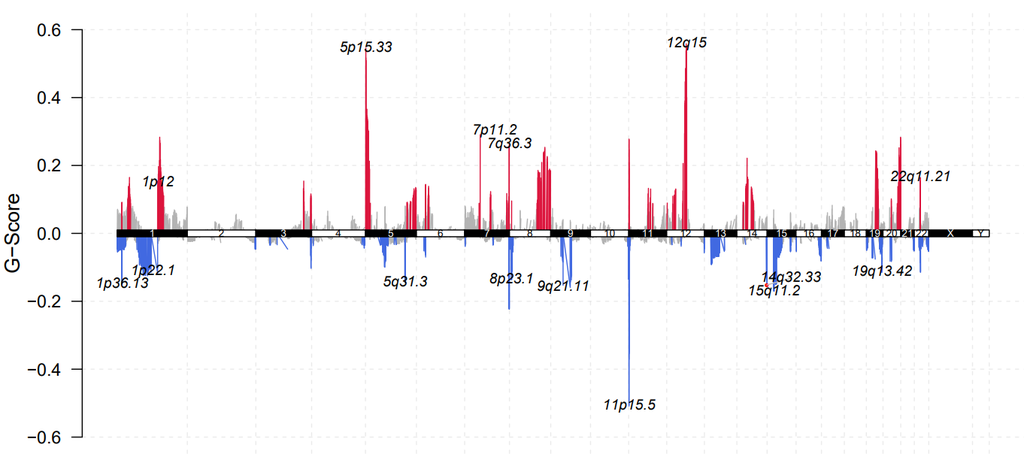

```r
library(maftools)
##Read in gistic output files
all.lesions="all_lesions.conf_95.txt"
amp.genes="amp_genes.conf_95.txt"
del.genes="del_genes.conf_95.txt"
scores.gistic="scores.gistic"
laml.gistic = readGistic(gisticAllLesionsFile = all.lesions,
                         gisticAmpGenesFile = amp.genes,
                         gisticDelGenesFile = del.genes,
                         gisticScoresFile = scores.gistic)
##Select the peak will be marked in the figure
peak=laml.gistic@cytoband.summary[order(laml.gistic@cytoband.summary$qvalues),][1:15]$Cytoband

gisticChromPlot(gistic=laml.gistic,
                color=c("#DC143C","#4169E1"),
                ref.build="hg19",
                fdrCutOff = 0.1,
                markBands=peak)
```

## Results and Q&A

**1.Using depth ratio or CNt**

GISTIC deconstructs each chromosome’s segmentation profile into a set of most likely explanatory events, and as part of the likelihood calculation it models the frequency of events across their amplitudes as an exponential distribution. With discrete data you have a decaying series of delta distributions, which behave quite differently from continuous distributions when you calculate p-values. In a sense, GISTIC 2.0 is somewhat tuned to relative copy number data, where the underlying discrete copies of DNA sequence are blurred and averaged by both noise and the varying purity/ploidy of the samples. In conclusion, using depth.ratio of sequenza output to run GISTIC.

**2.Control for ploidy or not**

GISTIC applies Ziggurat Deconstuction (ZD) to find focal events. The ZD algorithm will not be influenced by ploidy or arm level alternation, so GISTIC will get quite similiar results from data controlled for ploidy or not.

**3.Brief principle of GISTIC 2.0**

First, GISTIC uses ZD to dectect focal events.

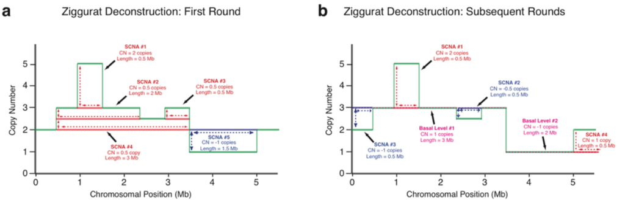

Then, for each events, G-score will be calculated as below.  
$A$ is the amplitude of copy number, $\alpha_{amp},\alpha_{del},\epsilon$ are scaling parameter that is fit across all samples (and separately for amplifications and deletions). $B = \{b1, b2, …\}$ represent the set of arm-level SCNAs $bi$ covering a marker, and $F = \{f1, f2, …\}$ represent the set of focal SCNA covering the marker.

$$\begin{align}
&P(f_i|B)=\begin{cases}
\alpha_{amp}e^{-\alpha_{amp}A},& A>0\\
(1+B)\alpha_{del}e^{-\alpha_{del}A},& A<0\ and\ B>-1\\
\epsilon\alpha_{del}e^{\alpha_{del}A},& A<0\ and\ B\leq-1\\
\end{cases}\\
&G=-ln(P(F|B))=-ln(\prod_{f_i\in F}P(f_i|B))=-\sum_{f_i\in F}ln(P(f_i|B))
\end{align}$$

There are a few more steps like determining peak boundary and calculate FDR q value. If you are interested, refer to supplementary matrial of GISTIC 2.0 article.

**4.G-score**

G-score is the negative log transformation of probability that the amplifications or deletions of a genomic site occur by chance. Large G-score indicates the site is under positive selection.

[^1]: Institute of Zoology, CAS wufengyuan@ioz.ac.cn